# Risk Factor Analysis

## Outcome Variable

**Outcome Variable:** pers_wasted624

## Predictor Variables

**Intervention Variable:** ever_stunted06

**Adjustment Set:**

- sex
- arm
- brthmon
- vagbrth
- single
- W_mage
- W_mhtcm
- W_mwtkg
- W_mbmi
- W_meducyrs
- W_feducyrs
- W_parity
- delta_brthmon
- delta_vagbrth
- delta_single
- delta_W_mage
- delta_W_mhtcm
- delta_W_mwtkg
- delta_W_mbmi
- delta_W_meducyrs
- delta_W_feducyrs
- delta_W_parity

## Stratifying Variables

The analysis was stratified on these variable(s):

- studyid
- country

## Data Summary

| studyid | country | ever_stunted06 | pers_wasted624 | n_cell | n |
| --- | --- | --- | --- | --- | --- |
| CMC-V-BCS-2002 | INDIA | 0 | 0 | 167 | 370 |
| CMC-V-BCS-2002 | INDIA | 0 | 1 | 11 | 370 |
| CMC-V-BCS-2002 | INDIA | 1 | 0 | 175 | 370 |
| CMC-V-BCS-2002 | INDIA | 1 | 1 | 17 | 370 |
| CMIN | BANGLADESH | 0 | 0 | 107 | 252 |
| CMIN | BANGLADESH | 0 | 1 | 3 | 252 |
| CMIN | BANGLADESH | 1 | 0 | 120 | 252 |
| CMIN | BANGLADESH | 1 | 1 | 22 | 252 |
| COHORTS | GUATEMALA | 0 | 0 | 555 | 1023 |
| COHORTS | GUATEMALA | 0 | 1 | 12 | 1023 |
| COHORTS | GUATEMALA | 1 | 0 | 427 | 1023 |
| COHORTS | GUATEMALA | 1 | 1 | 29 | 1023 |
| COHORTS | INDIA | 0 | 0 | 4740 | 6893 |
| COHORTS | INDIA | 0 | 1 | 420 | 6893 |
| COHORTS | INDIA | 1 | 0 | 1382 | 6893 |
| COHORTS | INDIA | 1 | 1 | 351 | 6893 |
| COHORTS | PHILIPPINES | 0 | 0 | 1889 | 2809 |
| COHORTS | PHILIPPINES | 0 | 1 | 108 | 2809 |
| COHORTS | PHILIPPINES | 1 | 0 | 694 | 2809 |
| COHORTS | PHILIPPINES | 1 | 1 | 118 | 2809 |
| CONTENT | PERU | 0 | 0 | 186 | 215 |
| CONTENT | PERU | 0 | 1 | 0 | 215 |
| CONTENT | PERU | 1 | 0 | 29 | 215 |
| CONTENT | PERU | 1 | 1 | 0 | 215 |
| EE | PAKISTAN | 0 | 0 | 83 | 373 |
| EE | PAKISTAN | 0 | 1 | 8 | 373 |
| EE | PAKISTAN | 1 | 0 | 241 | 373 |
| EE | PAKISTAN | 1 | 1 | 41 | 373 |
| GMS-Nepal | NEPAL | 0 | 0 | 339 | 590 |
| GMS-Nepal | NEPAL | 0 | 1 | 58 | 590 |

[output cut: 90 more lines]

The following strata were considered:

- studyid: CMC-V-BCS-2002, country: INDIA
- studyid: CMIN, country: BANGLADESH
- studyid: COHORTS, country: GUATEMALA
- studyid: COHORTS, country: INDIA
- studyid: COHORTS, country: PHILIPPINES
- studyid: CONTENT, country: PERU
- studyid: EE, country: PAKISTAN
- studyid: GMS-Nepal, country: NEPAL
- studyid: Guatemala BSC, country: GUATEMALA
- studyid: IRC, country: INDIA
- studyid: JiVitA-3, country: BANGLADESH
- studyid: JiVitA-4, country: BANGLADESH
- studyid: Keneba, country: GAMBIA
- studyid: LCNI-5, country: MALAWI
- studyid: MAL-ED, country: BANGLADESH
- studyid: MAL-ED, country: BRAZIL
- studyid: MAL-ED, country: INDIA
- studyid: MAL-ED, country: NEPAL
- studyid: MAL-ED, country: PERU
- studyid: MAL-ED, country: SOUTH AFRICA
- studyid: MAL-ED, country: TANZANIA, UNITED REPUBLIC OF
- studyid: NIH-Birth, country: BANGLADESH
- studyid: NIH-Crypto, country: BANGLADESH
- studyid: PROBIT, country: BELARUS
- studyid: PROVIDE, country: BANGLADESH
- studyid: ResPak, country: PAKISTAN
- studyid: SAS-CompFeed, country: INDIA
- studyid: SAS-FoodSuppl, country: INDIA
- studyid: TanzaniaChild2, country: TANZANIA, UNITED REPUBLIC OF
- studyid: ZVITAMBO, country: ZIMBABWE

### Dropped Strata

Some strata were dropped due to rare outcomes:

- studyid: CMIN, country: BANGLADESH
- studyid: CONTENT, country: PERU
- studyid: Guatemala BSC, country: GUATEMALA
- studyid: LCNI-5, country: MALAWI
- studyid: MAL-ED, country: BRAZIL
- studyid: MAL-ED, country: NEPAL
- studyid: MAL-ED, country: PERU
- studyid: MAL-ED, country: SOUTH AFRICA
- studyid: MAL-ED, country: TANZANIA, UNITED REPUBLIC OF
- studyid: PROBIT, country: BELARUS

## Methods Detail

We’re interested in the causal parameters $E[Y_a]$ for all values of $a \in \mathcal{A}$. These parameters represent the mean outcome if, possibly contrary to fact, we intervened to set all units to have $A=a$. Under the randomization and positivity assumptions, these are identified by the statistical parameters $\psi_a=E_W[E_{Y|A,W}(Y|A=a,W)]$. In addition, we’re interested in the mean of $Y$, $E[Y]$ under no intervention (the observed mean). We will estimate these parameters by using SuperLearner to fit the relevant likelihood factors – $E_{Y|A,W}(Y|A=a,W)$ and $p(A=a|W)$, and then updating our likelihood fit using a joint TMLE.

For unadjusted analyses ($W=\{\}$), initial likelihoods were estimated using Lrnr_glm to estimate the simple $E(Y|A)$ and Lrnr_mean to estimate $p(A)$. For adjusted analyses, a small library containing Lrnr_glmnet, Lrnr_xgboost, and Lrnr_mean was used.

Having estimated these parameters, we will then use the delta method to estimate relative risks and attributable risks relative to a prespecified baseline level of $A$.

# Results Detail

## Results Plots

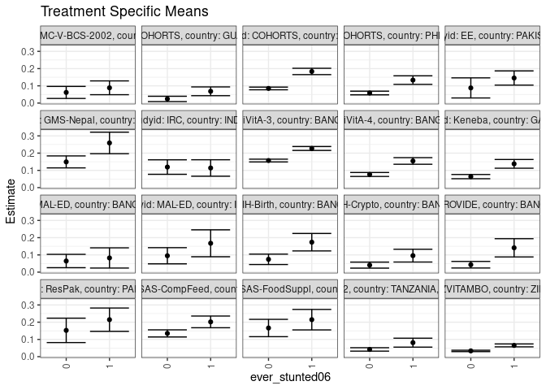

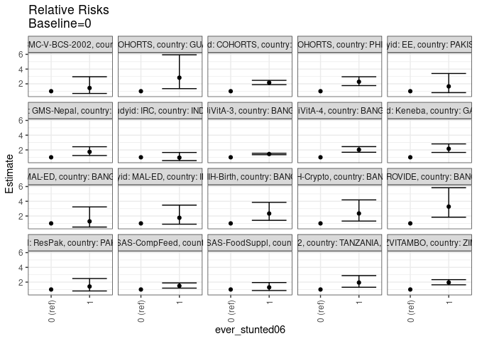

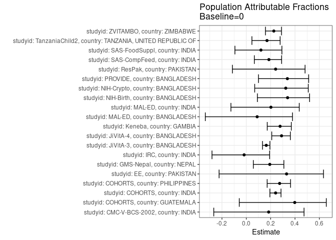

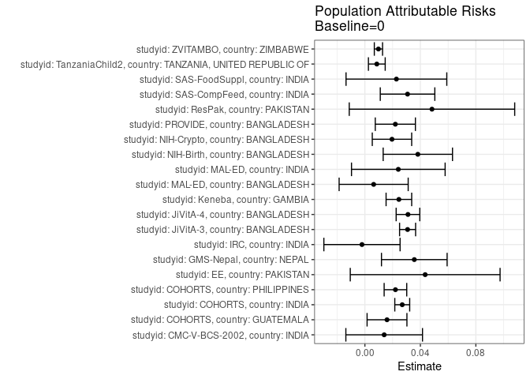

## Results Table

### Parameter: TSM

| studyid | country | intervention_level | baseline_level | estimate | ci_lower | ci_upper |
| --- | --- | --- | --- | --- | --- | --- |
| CMC-V-BCS-2002 | INDIA | 0 | NA | 0.0617719 | 0.0268141 | 0.0967298 |
| CMC-V-BCS-2002 | INDIA | 1 | NA | 0.0885126 | 0.0484674 | 0.1285579 |
| COHORTS | GUATEMALA | 0 | NA | 0.0241352 | 0.0086549 | 0.0396156 |
| COHORTS | GUATEMALA | 1 | NA | 0.0683072 | 0.0428513 | 0.0937631 |
| COHORTS | INDIA | 0 | NA | 0.0849284 | 0.0772008 | 0.0926560 |
| COHORTS | INDIA | 1 | NA | 0.1834701 | 0.1649915 | 0.2019488 |
| COHORTS | PHILIPPINES | 0 | NA | 0.0584322 | 0.0477412 | 0.0691232 |
| COHORTS | PHILIPPINES | 1 | NA | 0.1333436 | 0.1084929 | 0.1581943 |
| EE | PAKISTAN | 0 | NA | 0.0879121 | 0.0296544 | 0.1461697 |
| EE | PAKISTAN | 1 | NA | 0.1453901 | 0.1041938 | 0.1865863 |
| GMS-Nepal | NEPAL | 0 | NA | 0.1491303 | 0.1143448 | 0.1839157 |
| GMS-Nepal | NEPAL | 1 | NA | 0.2591425 | 0.1966780 | 0.3216070 |
| IRC | INDIA | 0 | NA | 0.1191748 | 0.0771729 | 0.1611767 |
| IRC | INDIA | 1 | NA | 0.1138787 | 0.0661822 | 0.1615751 |
| JiVitA-3 | BANGLADESH | 0 | NA | 0.1569937 | 0.1490086 | 0.1649788 |
| JiVitA-3 | BANGLADESH | 1 | NA | 0.2269692 | 0.2156609 | 0.2382776 |
| JiVitA-4 | BANGLADESH | 0 | NA | 0.0762248 | 0.0647401 | 0.0877095 |
| JiVitA-4 | BANGLADESH | 1 | NA | 0.1546198 | 0.1354395 | 0.1738002 |
| Keneba | GAMBIA | 0 | NA | 0.0637900 | 0.0516236 | 0.0759564 |
| Keneba | GAMBIA | 1 | NA | 0.1378043 | 0.1124768 | 0.1631319 |
| MAL-ED | BANGLADESH | 0 | NA | 0.0645161 | 0.0257599 | 0.1032723 |
| MAL-ED | BANGLADESH | 1 | NA | 0.0823529 | 0.0237900 | 0.1409159 |
| MAL-ED | INDIA | 0 | NA | 0.0950529 | 0.0481634 | 0.1419424 |
| MAL-ED | INDIA | 1 | NA | 0.1673571 | 0.0892748 | 0.2454394 |
| NIH-Birth | BANGLADESH | 0 | NA | 0.0743759 | 0.0441855 | 0.1045663 |
| NIH-Birth | BANGLADESH | 1 | NA | 0.1737422 | 0.1231385 | 0.2243458 |
| NIH-Crypto | BANGLADESH | 0 | NA | 0.0407457 | 0.0232735 | 0.0582180 |
| NIH-Crypto | BANGLADESH | 1 | NA | 0.0956956 | 0.0586259 | 0.1327653 |
| PROVIDE | BANGLADESH | 0 | NA | 0.0430898 | 0.0241672 | 0.0620124 |
| PROVIDE | BANGLADESH | 1 | NA | 0.1411138 | 0.0881586 | 0.1940690 |
| ResPak | PAKISTAN | 0 | NA | 0.1524968 | 0.0816830 | 0.2233105 |
| ResPak | PAKISTAN | 1 | NA | 0.2146310 | 0.1469503 | 0.2823117 |
| SAS-CompFeed | INDIA | 0 | NA | 0.1349532 | 0.1143188 | 0.1555877 |
| SAS-CompFeed | INDIA | 1 | NA | 0.2017862 | 0.1677513 | 0.2358211 |
| SAS-FoodSuppl | INDIA | 0 | NA | 0.1663329 | 0.1160917 | 0.2165740 |
| SAS-FoodSuppl | INDIA | 1 | NA | 0.2146608 | 0.1552544 | 0.2740673 |
| TanzaniaChild2 | TANZANIA, UNITED REPUBLIC OF | 0 | NA | 0.0419497 | 0.0320380 | 0.0518614 |
| TanzaniaChild2 | TANZANIA, UNITED REPUBLIC OF | 1 | NA | 0.0813199 | 0.0553534 | 0.1072864 |
| ZVITAMBO | ZIMBABWE | 0 | NA | 0.0334676 | 0.0293683 | 0.0375669 |
| ZVITAMBO | ZIMBABWE | 1 | NA | 0.0653526 | 0.0568577 | 0.0738475 |

### Parameter: E(Y)

| studyid | country | intervention_level | baseline_level | estimate | ci_lower | ci_upper |
| --- | --- | --- | --- | --- | --- | --- |
| CMC-V-BCS-2002 | INDIA | NA | NA | 0.0756757 | 0.0486905 | 0.1026609 |
| COHORTS | GUATEMALA | NA | NA | 0.0400782 | 0.0280529 | 0.0521035 |
| COHORTS | INDIA | NA | NA | 0.1118526 | 0.1044114 | 0.1192938 |
| COHORTS | PHILIPPINES | NA | NA | 0.0804557 | 0.0703953 | 0.0905161 |
| EE | PAKISTAN | NA | NA | 0.1313673 | 0.0970401 | 0.1656945 |
| GMS-Nepal | NEPAL | NA | NA | 0.1847458 | 0.1534039 | 0.2160876 |
| IRC | INDIA | NA | NA | 0.1170732 | 0.0859146 | 0.1482317 |
| JiVitA-3 | BANGLADESH | NA | NA | 0.1877787 | 0.1812440 | 0.1943134 |
| JiVitA-4 | BANGLADESH | NA | NA | 0.1072855 | 0.0967458 | 0.1178252 |
| Keneba | GAMBIA | NA | NA | 0.0882993 | 0.0766987 | 0.0998998 |
| MAL-ED | BANGLADESH | NA | NA | 0.0708333 | 0.0383085 | 0.1033581 |
| MAL-ED | INDIA | NA | NA | 0.1191489 | 0.0776405 | 0.1606574 |
| NIH-Birth | BANGLADESH | NA | NA | 0.1125461 | 0.0859151 | 0.1391771 |
| NIH-Crypto | BANGLADESH | NA | NA | 0.0602740 | 0.0429977 | 0.0775502 |
| PROVIDE | BANGLADESH | NA | NA | 0.0650407 | 0.0455353 | 0.0845460 |
| ResPak | PAKISTAN | NA | NA | 0.2008547 | 0.1494120 | 0.2522974 |
| SAS-CompFeed | INDIA | NA | NA | 0.1657061 | 0.1471754 | 0.1842367 |
| SAS-FoodSuppl | INDIA | NA | NA | 0.1890547 | 0.1507312 | 0.2273783 |
| TanzaniaChild2 | TANZANIA, UNITED REPUBLIC OF | NA | NA | 0.0505451 | 0.0409848 | 0.0601054 |
| ZVITAMBO | ZIMBABWE | NA | NA | 0.0432327 | 0.0393972 | 0.0470683 |

### Parameter: RR

| studyid | country | intervention_level | baseline_level | estimate | ci_lower | ci_upper |
| --- | --- | --- | --- | --- | --- | --- |
| CMC-V-BCS-2002 | INDIA | 0 | 0 | 1.0000000 | 1.0000000 | 1.000000 |
| CMC-V-BCS-2002 | INDIA | 1 | 0 | 1.4328940 | 0.6932329 | 2.961754 |
| COHORTS | GUATEMALA | 0 | 0 | 1.0000000 | 1.0000000 | 1.000000 |
| COHORTS | GUATEMALA | 1 | 0 | 2.8301874 | 1.3494745 | 5.935615 |
| COHORTS | INDIA | 0 | 0 | 1.0000000 | 1.0000000 | 1.000000 |
| COHORTS | INDIA | 1 | 0 | 2.1602912 | 1.8868900 | 2.473307 |
| COHORTS | PHILIPPINES | 0 | 0 | 1.0000000 | 1.0000000 | 1.000000 |
| COHORTS | PHILIPPINES | 1 | 0 | 2.2820234 | 1.7586435 | 2.961163 |
| EE | PAKISTAN | 0 | 0 | 1.0000000 | 1.0000000 | 1.000000 |
| EE | PAKISTAN | 1 | 0 | 1.6538121 | 0.8044198 | 3.400084 |
| GMS-Nepal | NEPAL | 0 | 0 | 1.0000000 | 1.0000000 | 1.000000 |
| GMS-Nepal | NEPAL | 1 | 0 | 1.7376921 | 1.2437041 | 2.427888 |
| IRC | INDIA | 0 | 0 | 1.0000000 | 1.0000000 | 1.000000 |
| IRC | INDIA | 1 | 0 | 0.9555602 | 0.5524157 | 1.652913 |
| JiVitA-3 | BANGLADESH | 0 | 0 | 1.0000000 | 1.0000000 | 1.000000 |
| JiVitA-3 | BANGLADESH | 1 | 0 | 1.4457216 | 1.3499716 | 1.548263 |
| JiVitA-4 | BANGLADESH | 0 | 0 | 1.0000000 | 1.0000000 | 1.000000 |
| JiVitA-4 | BANGLADESH | 1 | 0 | 2.0284713 | 1.6824747 | 2.445621 |
| Keneba | GAMBIA | 0 | 0 | 1.0000000 | 1.0000000 | 1.000000 |
| Keneba | GAMBIA | 1 | 0 | 2.1602805 | 1.6575457 | 2.815495 |
| MAL-ED | BANGLADESH | 0 | 0 | 1.0000000 | 1.0000000 | 1.000000 |
| MAL-ED | BANGLADESH | 1 | 0 | 1.2764706 | 0.5031874 | 3.238112 |
| MAL-ED | INDIA | 0 | 0 | 1.0000000 | 1.0000000 | 1.000000 |
| MAL-ED | INDIA | 1 | 0 | 1.7606726 | 0.8914774 | 3.477338 |
| NIH-Birth | BANGLADESH | 0 | 0 | 1.0000000 | 1.0000000 | 1.000000 |
| NIH-Birth | BANGLADESH | 1 | 0 | 2.3360007 | 1.4156617 | 3.854663 |
| NIH-Crypto | BANGLADESH | 0 | 0 | 1.0000000 | 1.0000000 | 1.000000 |
| NIH-Crypto | BANGLADESH | 1 | 0 | 2.3486062 | 1.3177338 | 4.185937 |
| PROVIDE | BANGLADESH | 0 | 0 | 1.0000000 | 1.0000000 | 1.000000 |
| PROVIDE | BANGLADESH | 1 | 0 | 3.2748741 | 1.8385125 | 5.833412 |
| ResPak | PAKISTAN | 0 | 0 | 1.0000000 | 1.0000000 | 1.000000 |
| ResPak | PAKISTAN | 1 | 0 | 1.4074460 | 0.7980218 | 2.482268 |
| SAS-CompFeed | INDIA | 0 | 0 | 1.0000000 | 1.0000000 | 1.000000 |
| SAS-CompFeed | INDIA | 1 | 0 | 1.4952304 | 1.1845318 | 1.887424 |
| SAS-FoodSuppl | INDIA | 0 | 0 | 1.0000000 | 1.0000000 | 1.000000 |
| SAS-FoodSuppl | INDIA | 1 | 0 | 1.2905495 | 0.8567392 | 1.944020 |
| TanzaniaChild2 | TANZANIA, UNITED REPUBLIC OF | 0 | 0 | 1.0000000 | 1.0000000 | 1.000000 |
| TanzaniaChild2 | TANZANIA, UNITED REPUBLIC OF | 1 | 0 | 1.9385077 | 1.3031101 | 2.883726 |
| ZVITAMBO | ZIMBABWE | 0 | 0 | 1.0000000 | 1.0000000 | 1.000000 |
| ZVITAMBO | ZIMBABWE | 1 | 0 | 1.9527102 | 1.6338173 | 2.333845 |

### Parameter: PAR

| studyid | country | intervention_level | baseline_level | estimate | ci_lower | ci_upper |
| --- | --- | --- | --- | --- | --- | --- |
| CMC-V-BCS-2002 | INDIA | 0 | NA | 0.0139037 | -0.0137236 | 0.0415310 |
| COHORTS | GUATEMALA | 0 | NA | 0.0159430 | 0.0015864 | 0.0302996 |
| COHORTS | INDIA | 0 | NA | 0.0269242 | 0.0215528 | 0.0322955 |
| COHORTS | PHILIPPINES | 0 | NA | 0.0220235 | 0.0138820 | 0.0301650 |
| EE | PAKISTAN | 0 | NA | 0.0434552 | -0.0105474 | 0.0974578 |
| GMS-Nepal | NEPAL | 0 | NA | 0.0356155 | 0.0119552 | 0.0592758 |
| IRC | INDIA | 0 | NA | -0.0021016 | -0.0295790 | 0.0253758 |
| JiVitA-3 | BANGLADESH | 0 | NA | 0.0307850 | 0.0250046 | 0.0365654 |
| JiVitA-4 | BANGLADESH | 0 | NA | 0.0310607 | 0.0225402 | 0.0395813 |
| Keneba | GAMBIA | 0 | NA | 0.0245092 | 0.0152778 | 0.0337407 |
| MAL-ED | BANGLADESH | 0 | NA | 0.0063172 | -0.0185779 | 0.0312123 |
| MAL-ED | INDIA | 0 | NA | 0.0240960 | -0.0096565 | 0.0578484 |
| NIH-Birth | BANGLADESH | 0 | NA | 0.0381702 | 0.0131788 | 0.0631617 |
| NIH-Crypto | BANGLADESH | 0 | NA | 0.0195283 | 0.0053215 | 0.0337350 |
| PROVIDE | BANGLADESH | 0 | NA | 0.0219508 | 0.0074860 | 0.0364156 |
| ResPak | PAKISTAN | 0 | NA | 0.0483579 | -0.0112820 | 0.1079979 |
| SAS-CompFeed | INDIA | 0 | NA | 0.0307528 | 0.0110892 | 0.0504164 |
| SAS-FoodSuppl | INDIA | 0 | NA | 0.0227218 | -0.0135950 | 0.0590387 |
| TanzaniaChild2 | TANZANIA, UNITED REPUBLIC OF | 0 | NA | 0.0085954 | 0.0025486 | 0.0146421 |
| ZVITAMBO | ZIMBABWE | 0 | NA | 0.0097651 | 0.0067926 | 0.0127376 |

### Parameter: PAF

| studyid | country | intervention_level | baseline_level | estimate | ci_lower | ci_upper |
| --- | --- | --- | --- | --- | --- | --- |
| CMC-V-BCS-2002 | INDIA | 0 | NA | 0.1837279 | -0.2672863 | 0.4742307 |
| COHORTS | GUATEMALA | 0 | NA | 0.3977968 | -0.0577047 | 0.6571362 |
| COHORTS | INDIA | 0 | NA | 0.2407112 | 0.1935786 | 0.2850891 |
| COHORTS | PHILIPPINES | 0 | NA | 0.2737345 | 0.1714225 | 0.3634130 |
| EE | PAKISTAN | 0 | NA | 0.3307917 | -0.2234703 | 0.6339594 |
| GMS-Nepal | NEPAL | 0 | NA | 0.1927811 | 0.0577201 | 0.3084833 |
| IRC | INDIA | 0 | NA | -0.0179513 | -0.2818425 | 0.1916129 |
| JiVitA-3 | BANGLADESH | 0 | NA | 0.1639431 | 0.1330085 | 0.1937739 |
| JiVitA-4 | BANGLADESH | 0 | NA | 0.2895146 | 0.2090246 | 0.3618139 |
| Keneba | GAMBIA | 0 | NA | 0.2775702 | 0.1720245 | 0.3696616 |
| MAL-ED | BANGLADESH | 0 | NA | 0.0891841 | -0.3366919 | 0.3793741 |
| MAL-ED | INDIA | 0 | NA | 0.2022343 | -0.1264557 | 0.4350154 |
| NIH-Birth | BANGLADESH | 0 | NA | 0.3391518 | 0.0908377 | 0.5196453 |
| NIH-Crypto | BANGLADESH | 0 | NA | 0.3239917 | 0.0690760 | 0.5091036 |
| PROVIDE | BANGLADESH | 0 | NA | 0.3374938 | 0.0999036 | 0.5123695 |
| ResPak | PAKISTAN | 0 | NA | 0.2407608 | -0.1143617 | 0.4827136 |
| SAS-CompFeed | INDIA | 0 | NA | 0.1855865 | 0.0659723 | 0.2898826 |
| SAS-FoodSuppl | INDIA | 0 | NA | 0.1201865 | -0.0935472 | 0.2921460 |
| TanzaniaChild2 | TANZANIA, UNITED REPUBLIC OF | 0 | NA | 0.1700533 | 0.0459930 | 0.2779806 |
| ZVITAMBO | ZIMBABWE | 0 | NA | 0.2258731 | 0.1573249 | 0.2888453 |